# Validation of rGFA functions

# 7. (N,D,K,sd.noise) = (4000, 43, 37, 0)

## 7.1 Simulate data

X and Y

```r
folder <- "N4000_D43_K37_noise0"
set.seed(123)
dat <- data.simu(N=4000, W_DxK=W, varIdx.by.block, sd.noise=0)
names(dat$Y.list) <- block.names
mynorm <- normalizeData(train=dat$Y.list, type="scaleFeatures")
Y <- do.call(cbind, mynorm$train)
```

## 7.2 Replicate GFA

```r
foreach(r = 1:15, .packages=c("GFA")) %dopar% {
  set.seed(r)
  res <- gfa(mynorm$train, opts=opts, K=43)
  save(res, file=paste0(mydir, "res/", folder, "/GFA_rep_", r, ".rda"))
}
```

With N=4000, individual GFA replicates returned K ranging from 31 to 35, closer to the true K=37. All replicates appeared to be converged.

```r
R <- 15
rep.summ <- data.frame(Replicate=1:R, conv=rep(NA, R), K=rep(NA, R))
gfaList_full <- list()
for(r in 1:R){
  load(paste0(mydir, "res/", folder, "/GFA_rep_", r, ".rda"))
  gfaList_full[[r]] <- res
  rep.summ$conv[r] <- res$conv
  rep.summ$K[r] <- res$K
}
rep.summ[rep.summ$conv>0.08,]
```

```
## [1] Replicate conv      K
## <0 rows> (or 0-length row.names)
```

```r
summary(rep.summ$conv)
```

```
##    Min. 1st Qu.  Median    Mean 3rd Qu.    Max.
## 0.04969 0.05084 0.05138 0.05155 0.05213 0.05402
```

```r
table(rep.summ$K)
```

```
##
## 31 32 33 34 35
##  1  3  6  1  4
```

Take the 10 replicates with lowest convergence stats, which returned K from 32 to 35:

```r
rep.use <- sort(rep.summ$conv, index.return=T)
# round(rep.summ$conv[rep.use$ix[1:10]], 3)
table(rep.summ$K[rep.use$ix[1:10]])
```

```
##
## 32 33 34 35
##  1  4  1  4
```

```r
gfaList_full <- gfaList_full[rep.use$ix[1:10]]
```

## 7.3 Identify robust factors

Compute replicate- and factor-specific effects

```r
R <- 15
rep.summ <- data.frame(Replicate=1:R, conv=rep(NA, R), K=rep(NA, R))
xw <- list()
for(r in 1:R){
  load(paste0(mydir, "res/", folder, "/GFA_rep_", r, ".rda"))
  xw[[r]] <- pmXW_by_factor(res)
  rep.summ$conv[r] <- res$conv
  rep.summ$K[r] <- res$K
}
rep.use <- sort(rep.summ$conv, index.return=T)
rep.use$ix[1:10]
xw <- xw[rep.use$ix[1:10]]
save(xw, file=paste0(mydir, "res/", folder, "/xw_by_rep_comp.rda"))
```

### 7.3.1 Using a list of the original GFA objects

```r
load(paste0(mydir, "res/", folder, "/xw_by_rep_comp.rda"))
tmp <- matrix(rep(NA, length(corGrids)*length(matchGrids)),
              nrow = length(corGrids), ncol = length(matchGrids),
              dimnames = list(corThr=corGrids, matchThr=matchGrids))

match_orig <- list(K.girds = tmp, mse.m = tmp, indices = rep( list(list()), length(corGrids) ))

for(i in 1:length(corGrids)){
  for (j in 6:length(matchGrids)){
    # rcomp <- matchComponents(comps = comps, maxK = 37, N=4000, D = 43, corThr = corGrids[i], matchThr = matchGrids[j])
    # save(rcomp, file=paste0(mydir, "res/", folder, "/rComp_corThr", corGrids[i], "_matchThr", matchGrids[j], ".rda"))
    load(paste0(mydir, "res/", folder, "/rComp_corThr", corGrids[i], "_matchThr", matchGrids[j], ".rda"))
    match_orig$K.girds[i,j] <- rcomp$Krobust
    match_orig$indices[[i]][[j]] <- rcomp$indices
    if(rcomp$Krobust>0){
      yhat <- apply(rcomp$effect, 1:2, sum, na.rm=T)
      match_orig$mse.m[i,j] <- mean((yhat - Y)^2)
    }
  }
}
save(match_orig, file=paste0(mydir, "res/", folder, "/match_orig.rda"))
```

The robustComponents() *revised to allow 0 macthed factors) would suggest K=35 factors

```r
load(paste0(mydir, "res/", folder, "/match_orig.rda"))

match_orig$K.girds
```

```
##       matchThr
## corThr 0.1 0.3 0.5 0.6 0.7 0.8 0.9
##    0.1  42  36  35  35  34  33  30
##    0.3  74  38  36  34  31  27  21
##    0.5 135  32  29  26  22  19  12
##    0.6 170  31  25  21  17  15   7
##    0.7 198  24  21  17  13   8   4
##    0.8 230  20  15  12   7   4   1
##    0.9 267  13   9   6   2   0   0
```

```r
round(match_orig$mse.m, 3)
```

```
##       matchThr
## corThr    0.1   0.3   0.5   0.6   0.7   0.8   0.9
##    0.1  0.085 0.011 0.010 0.010 0.020 0.022 0.042
##    0.3  1.878 0.061 0.037 0.031 0.052 0.115 0.249
##    0.5 11.107 0.092 0.128 0.185 0.268 0.286 0.499
##    0.6 21.072 0.153 0.244 0.331 0.435 0.471 0.704
##    0.7 25.672 0.295 0.377 0.447 0.654 0.703 0.752
##    0.8 37.039 0.570 0.636 0.667 0.725 0.752 0.825
##    0.9 51.322 0.674 0.714 0.746 0.820    NA    NA
```

```r
paste0("The min. MSE = ", round(min(match_orig$mse.m, na.rm=T), 3))
```

```
## [1] "The min. MSE = 0.01"
```

```r
tmp <- match_orig$K.girds
tmp[match_orig$mse.m > min(match_orig$mse.m, na.rm = T) | tmp==0] <- NA
tmp
```

```
##       matchThr
## corThr 0.1 0.3 0.5 0.6 0.7 0.8 0.9
##    0.1  NA  NA  35  35  NA  NA  NA
##    0.3  NA  NA  NA  NA  NA  NA  NA
##    0.5  NA  NA  NA  NA  NA  NA  NA
##    0.6  NA  NA  NA  NA  NA  NA  NA
##    0.7  NA  NA  NA  NA  NA  NA  NA
##    0.8  NA  NA  NA  NA  NA  NA  NA
##    0.9  NA  NA  NA  NA  NA  NA  NA
```

### 7.3.2. Using a list of posterior mean of reconstructed data

```r
load(paste0(mydir, "res/", folder, "/xw_by_rep_comp.rda"))
system.time(
  match.mse <- MSE.Grids(
    Ymtx=Y,                       ## the observed (normalized) data matrix (N x D)
    maxK = max(rep.summ$K),       ## the maximal K among the GFA replicates
    comps=xw,                     ## a list of GFA replicates with posterior medians
    corGrids=corGrids,            ## the grids of corThr values to be assessed
    matchGrids=matchGrids)        ## the grids of matchThr values to be assessed
) ## 2h:36m
save(match.mse, file=paste0(mydir, "res/", folder, "/MSE_xwList.rda"))
```

Numbers of matched factors for each (corThr, matchThr) combination:

```r
load(paste0(mydir, "res/", folder, "/MSE_xwList.rda"))
match.mse$K.grid
```

```
##       matchThr
## corThr 0.1 0.3 0.5 0.6 0.7 0.8 0.9
##    0.1  40  36  35  34  33  30  26
##    0.3  46  38  34  31  27  21  16
##    0.5  52  32  26  22  19  12   5
##    0.6  51  31  21  17  15   7   2
##    0.7  48  24  17  13   8   4   2
##    0.8  41  20  12   7   4   1   0
##    0.9  37  13   6   2   0   0   0
```

The 2 criteria suggested K=34 and K=30 respectively:

```r
opt.par <- optimizeK(K.grids=match.mse$K.grid, mse.array=match.mse$mse$all)
round(opt.par$mse.m, 3)
```

```
##       matchThr
## corThr   0.1   0.3   0.5   0.6   0.7   0.8   0.9
##    0.1 0.176 0.077 0.051 0.047 0.060 0.071 0.184
##    0.3 0.751 0.310 0.153 0.216 0.261 0.375 0.402
##    0.5 1.595 0.268 0.289 0.355 0.391 0.569 0.635
##    0.6 1.964 0.351 0.438 0.513 0.548 0.740 0.798
##    0.7 1.335 0.401 0.525 0.685 0.739 0.783 0.798
##    0.8 0.565 0.621 0.703 0.758 0.782 0.847   NaN
##    0.9 0.792 0.689 0.764 0.842   NaN   NaN   NaN
```

```r
paste0("The min. MSE = ", round(opt.par$mse.min, 3))
```

```
## [1] "The min. MSE = 0.047"
```

```r
paste0("The 1-SE MSE threshold = ", round(opt.par$mseThr, 3))
```

```
## [1] "The 1-SE MSE threshold = 0.087"
```

```r
paste0("min. MSE criterion gives ", opt.par$Krobust.min, " matched factors")
```

```
## [1] "min. MSE criterion gives 34 matched factors"
```

```r
paste0("1-SE MSE criterion gives ", opt.par$Krobust.1se, " matched factors")
```

```
## [1] "1-SE MSE criterion gives 30 matched factors"
```

```r
opt.par$par.min
```

```
##      opt.corThr opt.matchThr optK
## [1,]        0.1          0.6   34
```

```r
tmp <- match.mse$K.grid
tmp[opt.par$mse.m > opt.par$mseThr | tmp==0] <- NA
tmp[tmp > min(tmp, na.rm=T)] <- NA
paste0("The 1-SE MSE criterion suggested ", opt.par$Krobust.1se, " factors")
```

```
## [1] "The 1-SE MSE criterion suggested 30 factors"
```

```r
tmp
```

```
##       matchThr
## corThr 0.1 0.3 0.5 0.6 0.7 0.8 0.9
##    0.1  NA  NA  NA  NA  NA  30  NA
##    0.3  NA  NA  NA  NA  NA  NA  NA
##    0.5  NA  NA  NA  NA  NA  NA  NA
##    0.6  NA  NA  NA  NA  NA  NA  NA
##    0.7  NA  NA  NA  NA  NA  NA  NA
##    0.8  NA  NA  NA  NA  NA  NA  NA
##    0.9  NA  NA  NA  NA  NA  NA  NA
```

## 7.4 Agreement between estimated and the true factors

### 7.4.1 Robust factors identified using a list of posterior samples

```r
gfaList_p50 <- list()
for (r in 1:R){
  print( system.time(gfaList_p50[[r]] <- psSummary(gfa.res=gfaList_full[[r]], credible.lv=0.95)) )
}
save(gfaList_p50, file=paste0(mydir, "res/", folder, "/gfaList_p50.rda.rda"))
```

```r
load(paste0(mydir, "res/", folder, "/gfaList_p50.rda.rda"))
rob.ind <- list(indices=match_orig$indices[[1]][[4]])
vars.by.block <- gfaList_full[[1]]$groups ## variable indices separated by
# vars.by.block
ve_full <- rob.var.exp(models=gfaList_p50, indices=rob.ind, block.names=block.names, varIdx.by.block=vars.by.block, use.unmatched=T, by.block=T)
```

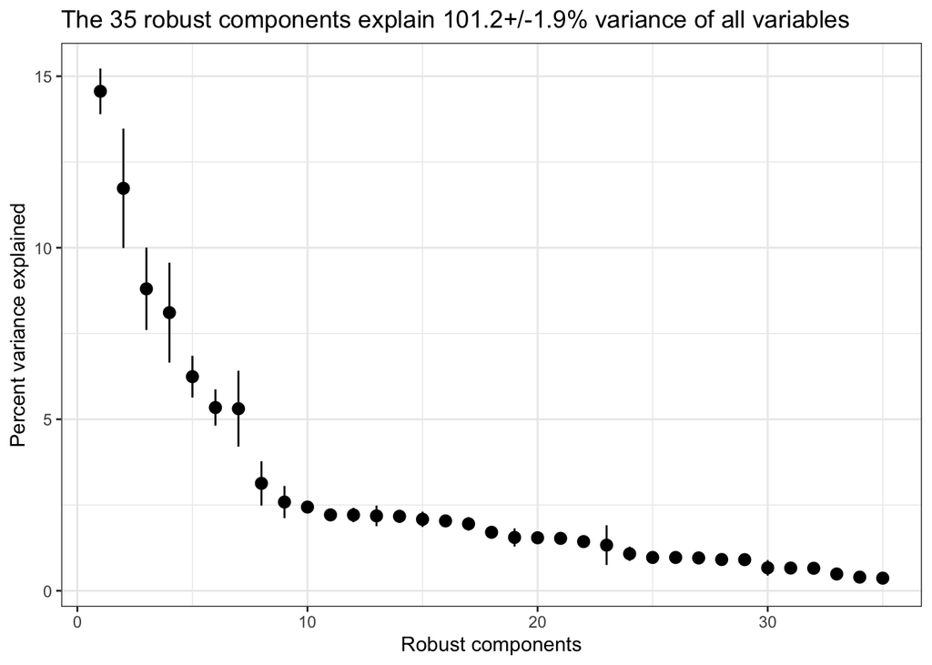

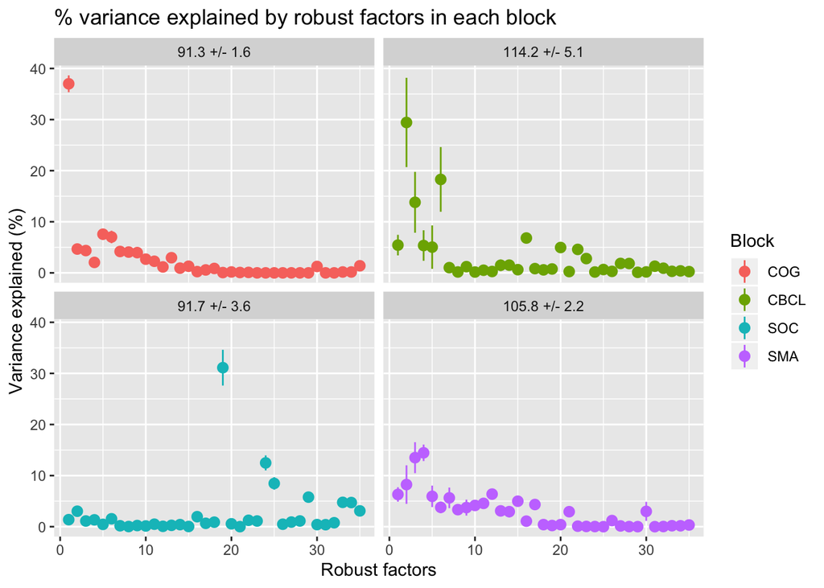

```r
tmp <- paste0(round(ve_full$ve.by.block$Mean, 1), ' +/- ', round(ve_full$ve.by.block$SE, 1))
block.labs <- c("COG" = tmp[1], "CBCL" = tmp[2], "SOC" = tmp[3], "SMA" = tmp[4])

p <- ggplot(ve_full$ve.by.block.comp,
            aes(x=Component, y=Mean, ymin=Mean-SE, ymax=Mean+SE, color=Block)) +
  geom_pointrange() +
  facet_wrap(~ Block, labeller = labeller(Block = block.labs)) +
  xlab('Robust factors') + ylab('Variance explained (%)') +
  ggtitle("% variance explained by robust factors in each block")
p
```

```r
block4vars <- c(rep("COG", length(varIdx.by.block[[1]])),
                rep("CBCL", length(varIdx.by.block[[2]])),
                rep("SOC", length(varIdx.by.block[[3]])),
                rep("SMA", length(varIdx.by.block[[4]])))
cbclabels <- c("Anxious/Depressed","Withdrawn","Somatic Sx","Social Problems","Thought Problems","Attention Problems","Rule Breaking","Aggressive Behavior","Internalizing","Externalizing","Total Problems")
coglabels <- c("Picture Vocabulary","Flanker Tes","List Sorting","Card Sorting","Pattern Comparison","Picture Sequence","Oral Reading Recog","Fluid Composite","Crystallized Composite","Cognition Total","RAVLT Short Delay","RAVLT Long Delay","WISC-V Matrix Reasoning")
soclabels <- c("P: Family Conflict","Y: Family Conflict","P: CPBRI Acceptance",
               "SC: CPBRI Acceptance","P: Prosocial Behavior","Y: Prosocial",
               "Y: Parental Monitoring")
smalabels <- c("WD TV/Movie","WD Videos","WD Games","WD Texting","WD Social Network","WD Chat",
               "WE TV/Movie","WE Videos","WE Games","WE Texting","WE Social Network","WE Chat")
allvarlabs <- c(coglabels, cbclabels, soclabels, smalabels)
```

```r
rWX_full <- rob_wx(models=gfaList_p50, indices=ve_full$indices, block.labs=block4vars, var.labs=allvarlabs)
save(rWX_full, file=paste0(mydir, "res/", folder, "/rWX_full.rda"))
```

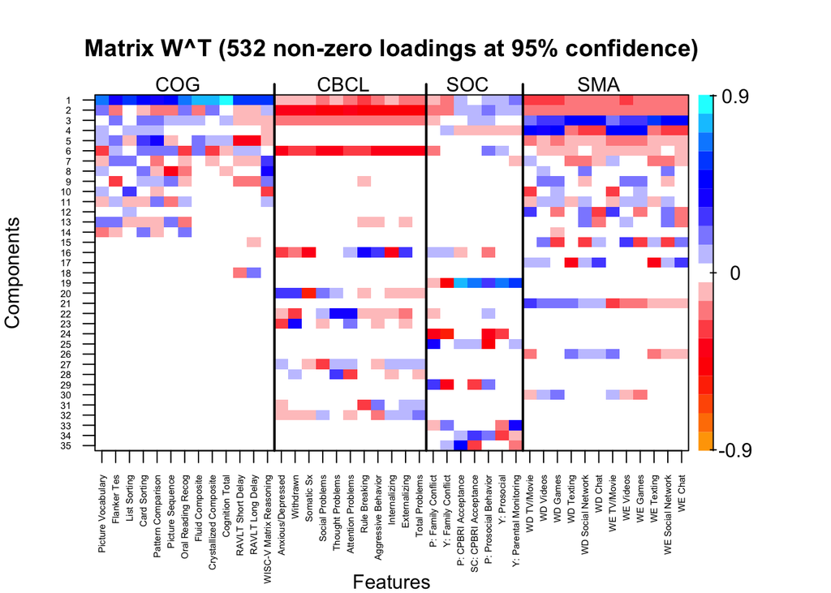

```r
load(paste0(mydir, "res/", folder, "/rWX_full.rda"))
gfa_heatmap(robW=rWX_full, block.names=block.names, varIdx.by.block=varIdx.by.block, conf.level=0.95, heatmap.rep=FALSE, factor.order=NULL)
```

Similarity (correlations) between true factor loadings (rows) and estimated (columns)

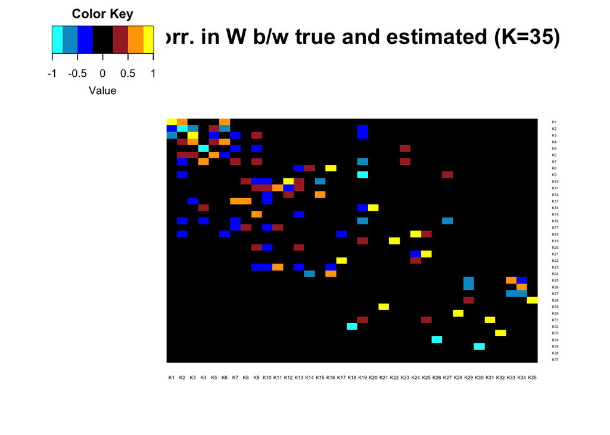

```r
# dim(rWX_full$w.med)
sim_true_full <- matrix(NA, ncol(W), ncol(rWX_full$w.med),
                        dimnames=list(True=paste0("K", 1:ncol(W)), Full=paste0("K", 1:ncol(rWX_full$w.med))))
for (i in 1:ncol(W)){
  for(j in 1:ncol(rWX_full$w.med)){
    sim_true_full[i,j] <- cor(W[,i], rWX_full$w.med[,j])
  }
}
# round(sim_true_full, 1)

heatmap.2(sim_true_full, col=c('cyan','deepskyblue3',"blue",'black','brown','orange',"yellow"),
          dendrogram='none', scale="none",
          cexRow = 0.3, cexCol=0.4, Colv=F, Rowv=F, density.info="none", trace="none",
          srtCol=0,   adjCol = c(0.5,1), symkey = F,
          breaks = c(-1.0, -0.8, -0.5, -0.2, 0.2, 0.5, 0.8, 1.0),
          main="Corr. in W b/w true and estimated (K=35)" )
```

True (Row 1):Estimated (Row 2) factor matching (e.g. true factor K4 was matched to estimated K6)

```r
apply(abs(sim_true_full), 1, which.max)
```

```
##  K1  K2  K3  K4  K5  K6  K7  K8  K9 K10 K11 K12 K13 K14 K15 K16 K17 K18
##   1   2   3   6   4   5  19  16  19  12  11  15   8  20   9  19   7  24
## K19 K20 K21 K22 K23 K24 K25 K26 K27 K28 K29 K30 K31 K32 K33 K34 K35 K36
##  22  10  25  17  11  16  33  29  33  35  21  28  31  18  32  26  30  28
## K37
##  15
```

Estimated (Row 1):True (Row 2) factor matching (e.g. Estimated K4 was matched to true K5)

```r
apply(abs(sim_true_full), 2, which.max)
```

```
##  K1  K2  K3  K4  K5  K6  K7  K8  K9 K10 K11 K12 K13 K14 K15 K16 K17 K18
##   1   2   3   5   6   4  13  13  15  11  23  10  10  24  12   8  22  32
## K19 K20 K21 K22 K23 K24 K25 K26 K27 K28 K29 K30 K31 K32 K33 K34 K35
##   9  14  29  19   7  18  21  34  16  30  26  35  31  33  27  27  28
```

```r
Distribution of absolute values of correlations:
summary(round(apply(abs(sim_true_full), 2, max), 1))
ggplot(data.frame(corr=apply(abs(sim_true_full), 2, max)), aes(x=corr)) + geom_density() + ggtitle("Distribution of absolute values of correlations")
```

### 7.4.2 Robust factors identified using a list of posterior mean of reconstructed data and min-MSE criterion

```r
rob.ind <- list(indices=match.mse$indices[[1]][[4]])
ve_p50.min <- rob.var.exp(models=gfaList_p50, indices=rob.ind, block.names=block.names, varIdx.by.block=vars.by.block, use.unmatched=T, by.block=T)
```

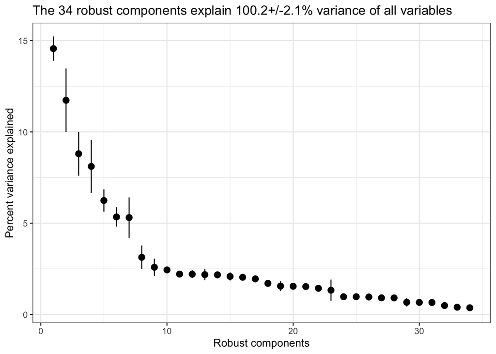

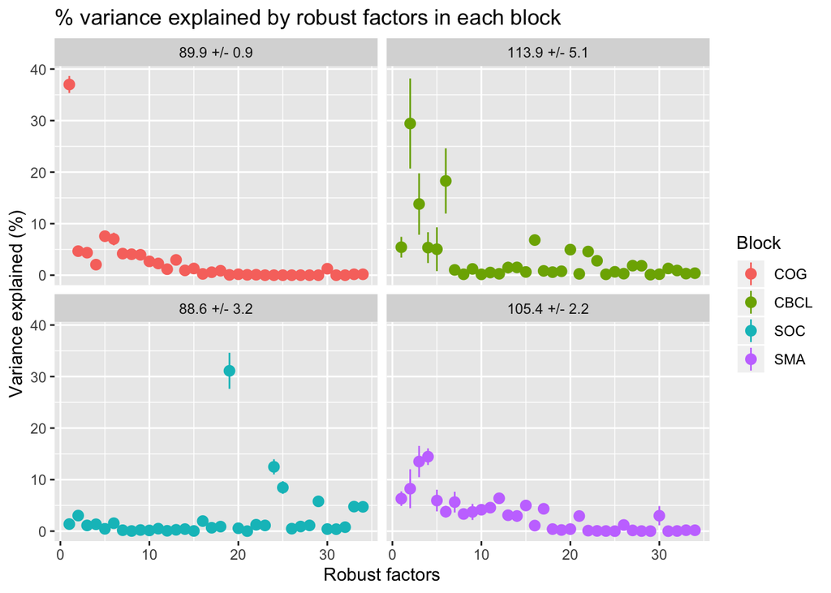

```r
tmp <- paste0(round(ve_p50.min$ve.by.block$Mean, 1), ' +/- ', round(ve_p50.min$ve.by.block$SE, 1))
block.labs <- c("COG" = tmp[1], "CBCL" = tmp[2], "SOC" = tmp[3], "SMA" = tmp[4])

p <- ggplot(ve_p50.min$ve.by.block.comp,
            aes(x=Component, y=Mean, ymin=Mean-SE, ymax=Mean+SE, color=Block)) +
  geom_pointrange() +
  facet_wrap(~ Block, labeller = labeller(Block = block.labs)) +
  xlab('Robust factors') + ylab('Variance explained (%)') +
  ggtitle("% variance explained by robust factors in each block")
p
```

```r
rWX_p50.min <- rob_wx(models=gfaList_p50, indices=ve_p50.min$indices, block.labs=block4vars, var.labs=allvarlabs)
save(rWX_p50.min, file=paste0(mydir, "res/", folder, "/rWX_p50.min.rda"))
```

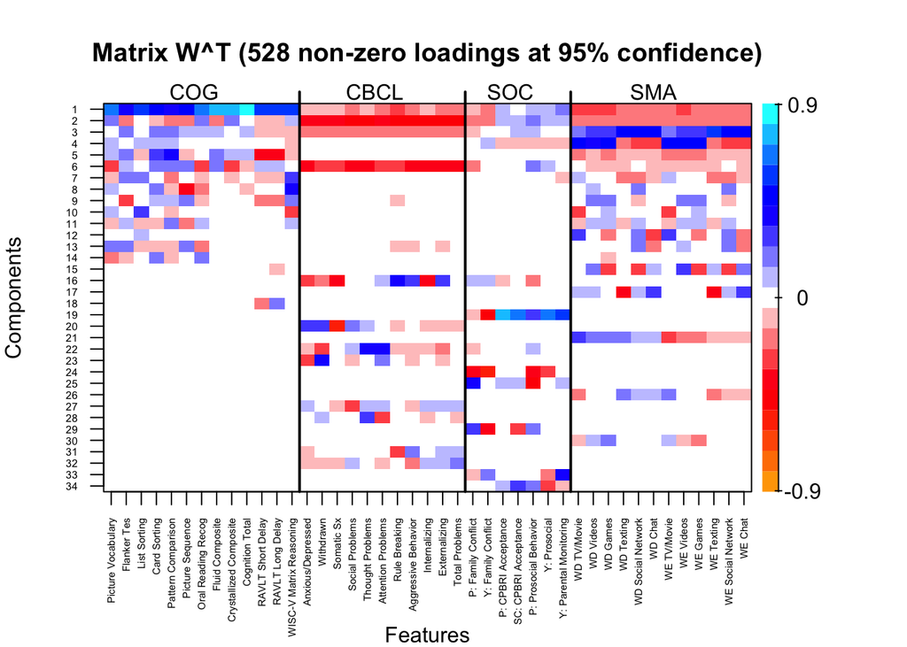

```r
load(paste0(mydir, "res/", folder, "/rWX_p50.min.rda"))
gfa_heatmap(robW=rWX_p50.min, block.names=block.names, varIdx.by.block=varIdx.by.block, conf.level=0.95, heatmap.rep=FALSE, factor.order=NULL)
```

Similarity (correlations) between true factor loadings (rows) and estimated (columns)

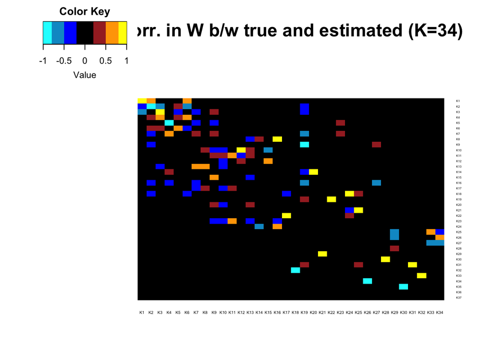

```r
sim_true_p50.min <- matrix(NA, ncol(W), ncol(rWX_p50.min$w.med),
                        dimnames=list(True=paste0("K", 1:ncol(W)), p50.min=paste0("K", 1:ncol(rWX_p50.min$w.med))))
for (i in 1:ncol(W)){
  for(j in 1:ncol(rWX_p50.min$w.med)){
    sim_true_p50.min[i,j] <- cor(W[,i], rWX_p50.min$w.med[,j])
  }
}
# round(sim_true_p50.min, 1)

heatmap.2(sim_true_p50.min, col=c('cyan','deepskyblue3',"blue",'black','brown','orange',"yellow"),
          dendrogram='none', scale="none",
          cexRow = 0.3, cexCol=0.4, Colv=F, Rowv=F, density.info="none", trace="none",
          srtCol=0,   adjCol = c(0.5,1), symkey = F,
          breaks = c(-1.0, -0.8, -0.5, -0.2, 0.2, 0.5, 0.8, 1.0),
          main="Corr. in W b/w true and estimated (K=34)" )
```

True (Row 1):Estimated (Row 2) factor matching (e.g. true factor K4 was matched to estimated K6)

```r
apply(abs(sim_true_p50.min), 1, which.max)
```

```
##  K1  K2  K3  K4  K5  K6  K7  K8  K9 K10 K11 K12 K13 K14 K15 K16 K17 K18
##   1   2   3   6   4   5  19  16  19  12  11  15   8  20   9  19   7  24
## K19 K20 K21 K22 K23 K24 K25 K26 K27 K28 K29 K30 K31 K32 K33 K34 K35 K36
##  22  10  25  17  11  16  33  29  33  29  21  28  31  18  32  26  30  28
## K37
##  15
```

Estimated (Row 1):True (Row 2) factor matching (e.g. Estimated K4 was matched to true K5)

```r
apply(abs(sim_true_p50.min), 2, which.max)
```

```
##  K1  K2  K3  K4  K5  K6  K7  K8  K9 K10 K11 K12 K13 K14 K15 K16 K17 K18
##   1   2   3   5   6   4  13  13  15  11  23  10  10  24  12   8  22  32
## K19 K20 K21 K22 K23 K24 K25 K26 K27 K28 K29 K30 K31 K32 K33 K34
##   9  14  29  19   7  18  21  34  16  30  26  35  31  33  27  27
```

```r
## Distribution of absolute values of correlations:
summary(round(apply(abs(sim_true_p50.min), 2, max), 1))
ggplot(data.frame(corr=apply(abs(sim_true_p50.min), 2, max)), aes(x=corr)) + geom_density() + ggtitle("Distribution of absolute values of correlations")
```

#### 7.4.3 Robust factors identified using a list of posterior mean of reconstructed data and 1-SE criterion

```r
rob.ind <- list(indices=match.mse$indices[[1]][[6]])
ve_p50.1se <- rob.var.exp(models=gfaList_p50, indices=rob.ind, block.names=block.names, varIdx.by.block=vars.by.block, use.unmatched=T, by.block=T)
```

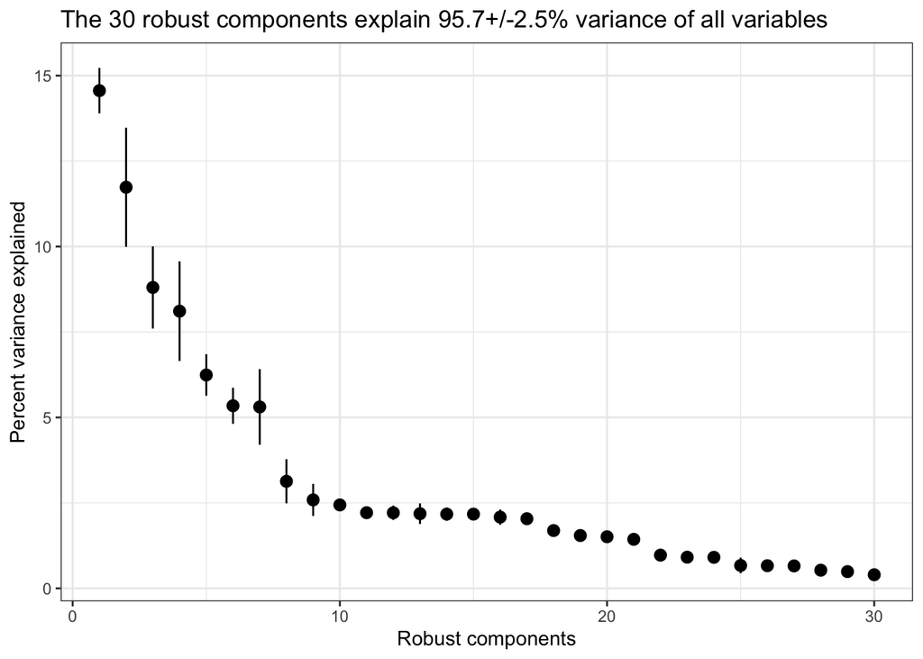

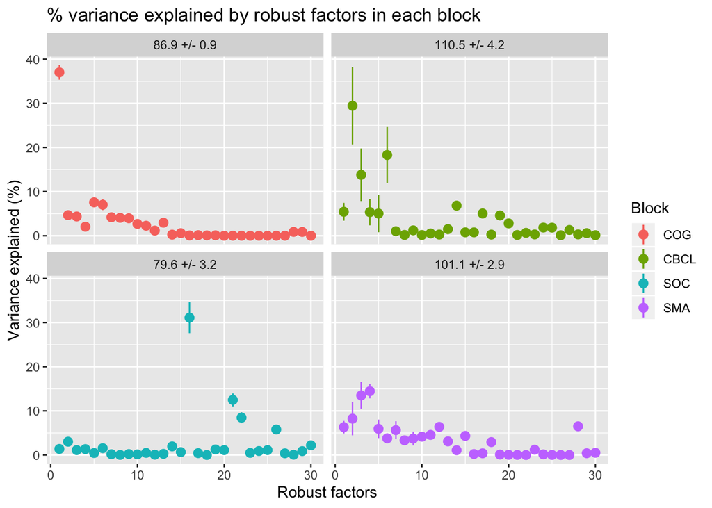

```r
tmp <- paste0(round(ve_p50.1se$ve.by.block$Mean, 1), ' +/- ', round(ve_p50.1se$ve.by.block$SE, 1))
block.labs <- c("COG" = tmp[1], "CBCL" = tmp[2], "SOC" = tmp[3], "SMA" = tmp[4])

p <- ggplot(ve_p50.1se$ve.by.block.comp,
            aes(x=Component, y=Mean, ymin=Mean-SE, ymax=Mean+SE, color=Block)) +
  geom_pointrange() +
  facet_wrap(~ Block, labeller = labeller(Block = block.labs)) +
  xlab('Robust factors') + ylab('Variance explained (%)') +
  ggtitle("% variance explained by robust factors in each block")
p
```

```r
rWX_p50.1se <- rob_wx(models=gfaList_p50, indices=ve_p50.1se$indices, block.labs=block4vars, var.labs=allvarlabs)
save(rWX_p50.1se, file=paste0(mydir, "res/", folder, "/rWX_p50.1se.rda"))
```

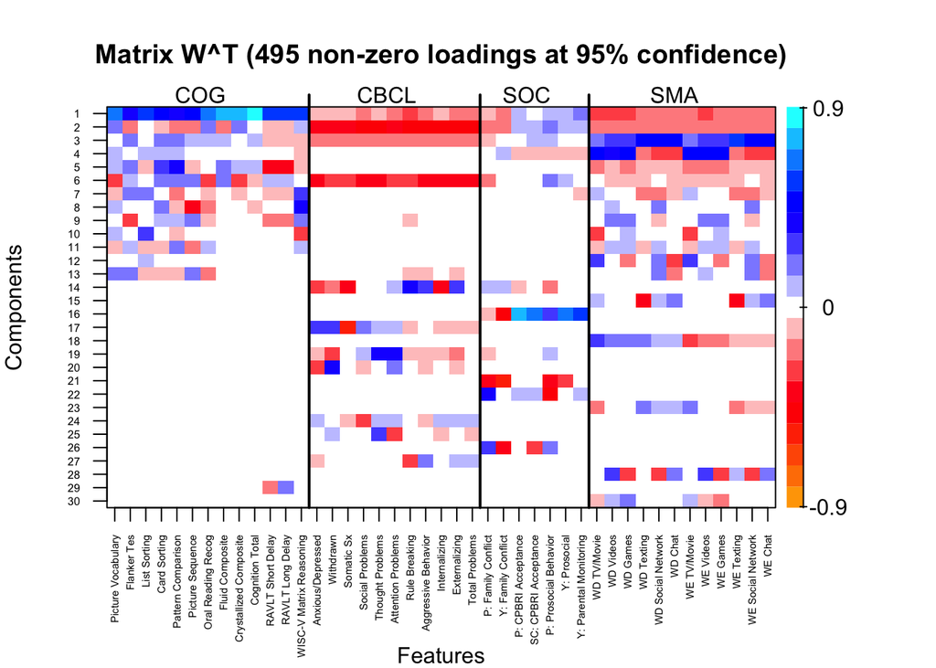

```r
load(paste0(mydir, "res/", folder, "/rWX_p50.1se.rda"))
gfa_heatmap(robW=rWX_p50.1se, block.names=block.names, varIdx.by.block=varIdx.by.block, conf.level=0.95, heatmap.rep=FALSE, factor.order=NULL)
```

Similarity (correlations) between true factor loadings (rows) and estimated (columns)

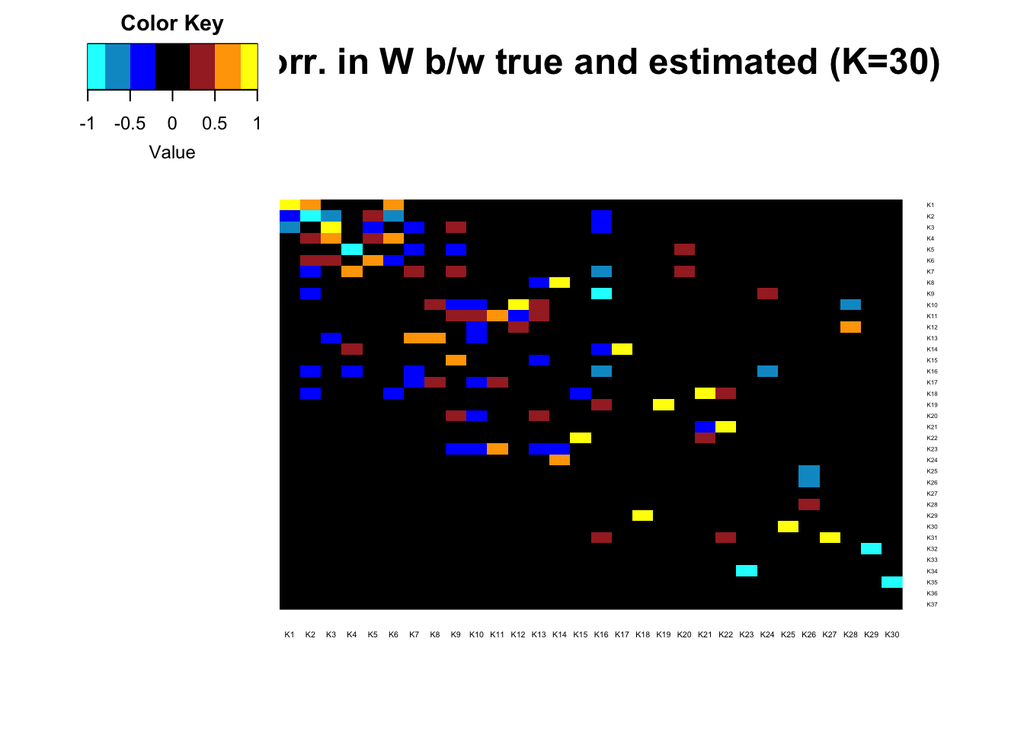

```r
sim_true_p50.1se <- matrix(NA, ncol(W), ncol(rWX_p50.1se$w.med),
                        dimnames=list(True=paste0("K", 1:ncol(W)), p50.1se=paste0("K", 1:ncol(rWX_p50.1se$w.med))))
for (i in 1:ncol(W)){
  for(j in 1:ncol(rWX_p50.1se$w.med)){
    sim_true_p50.1se[i,j] <- cor(W[,i], rWX_p50.1se$w.med[,j])
  }
}
# round(sim_true_p50.min, 1)

heatmap.2(sim_true_p50.1se, col=c('cyan','deepskyblue3',"blue",'black','brown','orange',"yellow"),
          dendrogram='none', scale="none",
          cexRow = 0.3, cexCol=0.4, Colv=F, Rowv=F, density.info="none", trace="none",
          srtCol=0,   adjCol = c(0.5,1), symkey = F,
          breaks = c(-1.0, -0.8, -0.5, -0.2, 0.2, 0.5, 0.8, 1.0),
          main="Corr. in W b/w true and estimated (K=30)" )
```

True (Row 1):Estimated (Row 2) factor matching (e.g. true factor K4 was matched to estimated K6)

```r
apply(abs(sim_true_p50.1se), 1, which.max)
```

```
##  K1  K2  K3  K4  K5  K6  K7  K8  K9 K10 K11 K12 K13 K14 K15 K16 K17 K18
##   1   2   3   6   4   5  16  14  16  12  11  28   8  17   9  16   7  21
## K19 K20 K21 K22 K23 K24 K25 K26 K27 K28 K29 K30 K31 K32 K33 K34 K35 K36
##  19  10  22  15  11  14  26  26   2  26  18  25  27  29  22  23  30  25
## K37
##  11
```

Estimated (Row 1):True (Row 2) factor matching (e.g. Estimated K4 was matched to true K5)

```r
apply(abs(sim_true_p50.1se), 2, which.max)
```

```
##  K1  K2  K3  K4  K5  K6  K7  K8  K9 K10 K11 K12 K13 K14 K15 K16 K17 K18
##   1   2   3   5   6   4  13  13  15  11  23  10  10   8  22   9  14  29
## K19 K20 K21 K22 K23 K24 K25 K26 K27 K28 K29 K30
##  19   7  18  21  34  16  30  26  31  12  32  35
```

```r
## Distribution of absolute values of correlations:
summary(round(apply(abs(sim_true_p50.1se), 2, max), 1))
ggplot(data.frame(corr=apply(abs(sim_true_p50.1se), 2, max)), aes(x=corr)) + geom_density() + ggtitle("Distribution of absolute values of correlations")
```

## 7.5 Consistency of matching

### 7.5.1 Using full posterior samples

Estimated (Row 1):True (Row 2) factor matching

```r
apply(abs(sim_true_full), 2, which.max)
```

```
##  K1  K2  K3  K4  K5  K6  K7  K8  K9 K10 K11 K12 K13 K14 K15 K16 K17 K18
##   1   2   3   5   6   4  13  13  15  11  23  10  10  24  12   8  22  32
## K19 K20 K21 K22 K23 K24 K25 K26 K27 K28 K29 K30 K31 K32 K33 K34 K35
##   9  14  29  19   7  18  21  34  16  30  26  35  31  33  27  27  28
```

Estimated factors were matched to the true factors (K10, K13, & K27) twice

```r
table(apply(abs(sim_true_full), 2, which.max))
```

```
##
##  1  2  3  4  5  6  7  8  9 10 11 12 13 14 15 16 18 19 21 22 23 24 26 27 28
##  1  1  1  1  1  1  1  1  1  2  1  1  2  1  1  1  1  1  1  1  1  1  1  2  1
## 29 30 31 32 33 34 35
##  1  1  1  1  1  1  1
```

True factors not matched

```r
paste0("K", 1:37)[!c(1:37) %in% apply(abs(sim_true_full), 2, which.max)]
```

```
## [1] "K17" "K20" "K25" "K36" "K37"
```

True variance explained by the unmatched factors

```r
paste0(round(sum(W[, c(17, 20, 25, 36, 37)]^2)/43*100, 1), "%")
```

```
## [1] "4.4%"
```

### 7.5.2 Using posterior means of factor effects and min-MSE criterion

Estimated (Row 1):True (Row 2) factor matching.

```r
apply(abs(sim_true_p50.min), 2, which.max)
```

```
##  K1  K2  K3  K4  K5  K6  K7  K8  K9 K10 K11 K12 K13 K14 K15 K16 K17 K18
##   1   2   3   5   6   4  13  13  15  11  23  10  10  24  12   8  22  32
## K19 K20 K21 K22 K23 K24 K25 K26 K27 K28 K29 K30 K31 K32 K33 K34
##   9  14  29  19   7  18  21  34  16  30  26  35  31  33  27  27
```

Estimated factors were matched to the true factors (K10, K13, & K27) twice

```r
table(apply(abs(sim_true_p50.min), 2, which.max))
```

```
##
##  1  2  3  4  5  6  7  8  9 10 11 12 13 14 15 16 18 19 21 22 23 24 26 27 29
##  1  1  1  1  1  1  1  1  1  2  1  1  2  1  1  1  1  1  1  1  1  1  1  2  1
## 30 31 32 33 34 35
##  1  1  1  1  1  1
```

True factors not matched (1 additional true factor K28 was not matched)

```r
paste0("K", 1:37)[!c(1:37) %in% apply(abs(sim_true_p50.min), 2, which.max)]
```

```
## [1] "K17" "K20" "K25" "K28" "K36" "K37"
```

True variance explained by the unmatched factors

```r
paste0(round(sum(W[, c(17, 20, 25, 28, 36, 37)]^2)/43*100, 1), "%")
```

```
## [1] "5.2%"
```

### 7.5.3 Using posterior means of factor effects and 1-SE criterion

Estimated (Row 1):True (Row 2) factor matching.

```r
apply(abs(sim_true_p50.1se), 2, which.max)
```

```
##  K1  K2  K3  K4  K5  K6  K7  K8  K9 K10 K11 K12 K13 K14 K15 K16 K17 K18
##   1   2   3   5   6   4  13  13  15  11  23  10  10   8  22   9  14  29
## K19 K20 K21 K22 K23 K24 K25 K26 K27 K28 K29 K30
##  19   7  18  21  34  16  30  26  31  12  32  35
```

Estimated factors were matched to the true factors (K10, K13) twice

```r
table(apply(abs(sim_true_p50.1se), 2, which.max))
```

```
##
##  1  2  3  4  5  6  7  8  9 10 11 12 13 14 15 16 18 19 21 22 23 26 29 30 31
##  1  1  1  1  1  1  1  1  1  2  1  1  2  1  1  1  1  1  1  1  1  1  1  1  1
## 32 34 35
##  1  1  1
```

True factors not matched ( additional true factors not matched K24, K27, K28, K33)

```r
paste0("K", 1:37)[!c(1:37) %in% apply(abs(sim_true_p50.1se), 2, which.max)]
```

```
## [1] "K17" "K20" "K24" "K25" "K27" "K28" "K33" "K36" "K37"
```

True variance explained by the unmatched factors

```r
paste0(round(sum(W[, c(17, 20, 25, 36, 37, 24, 27, 28, 33)]^2)/43*100, 1), "%")
```

```
## [1] "7.9%"
```

# Conclusions

Based on this small scale simulation,